# assignment #2

20182477 김효재

2021 3 30

================================================================================================= ##1번 1.1) ID와 ZIP.code를 feature에서 제외하기 1.2) z-score normalization 활용한 정규화하기 1.3) 첫 4000명의 데이터를 training set으로, 나머지 1000명의 데이터를 test set으로 사용하여 Training set과 test set에서의 PersonalLoan 값의 분포를 비교하기

```r
#먼저 사용할 패키지를 불러온다.
library(class)
library(ggplot2)
library(caret)
#bank변수에 CommonBank.csv 데이터 파일을 불러오고, 데이터 구조를 확인한다.
bank <- read.csv("C:/Users/chk/Documents/CommonBank.csv")
str(bank)
```

```
## 'data.frame':    5000 obs. of  14 variables:
##  $ ID               : int  1 2 3 4 5 6 7 8 9 10 ...
##  $ Age              : int  25 45 39 35 35 37 53 50 35 34 ...
##  $ Experience       : int  1 19 15 9 8 13 27 24 10 9 ...
##  $ Income           : int  49 34 11 100 45 29 72 22 81 180 ...
##  $ ZIP.Code         : int  91107 90089 94720 94112 91330 92121 91711 93943 90089 93023 ...
##  $ Family           : int  4 3 1 1 4 4 2 1 3 1 ...
##  $ CCAvg            : num  1.6 1.5 1 2.7 1 0.4 1.5 0.3 0.6 8.9 ...
##  $ Education        : int  1 1 1 2 2 2 2 3 2 3 ...
##  $ Mortgage         : int  0 0 0 0 0 155 0 0 104 0 ...
##  $ PersonalLoan     : int  0 0 0 0 0 0 0 0 0 1 ...
##  $ SecuritiesAccount: int  1 1 0 0 0 0 0 0 0 0 ...
##  $ CDAccount        : int  0 0 0 0 0 0 0 0 0 0 ...
##  $ Online           : int  0 0 0 0 0 1 1 0 1 0 ...
##  $ CreditCard       : int  0 0 0 0 1 0 0 1 0 0 ...
```

```r
# 1-1) ID 와 ZIP codes를 feature에서 제외시킨 후 확인한다.
bank <- bank[,c(-1,-5)]
str(bank)
```

```
## 'data.frame':    5000 obs. of  12 variables:
##  $ Age              : int  25 45 39 35 35 37 53 50 35 34 ...
##  $ Experience       : int  1 19 15 9 8 13 27 24 10 9 ...
##  $ Income           : int  49 34 11 100 45 29 72 22 81 180 ...
##  $ Family           : int  4 3 1 1 4 4 2 1 3 1 ...
##  $ CCAvg            : num  1.6 1.5 1 2.7 1 0.4 1.5 0.3 0.6 8.9 ...
##  $ Education        : int  1 1 1 2 2 2 2 3 2 3 ...
##  $ Mortgage         : int  0 0 0 0 0 155 0 0 104 0 ...
##  $ PersonalLoan     : int  0 0 0 0 0 0 0 0 0 1 ...
##  $ SecuritiesAccount: int  1 1 0 0 0 0 0 0 0 0 ...
##  $ CDAccount        : int  0 0 0 0 0 0 0 0 0 0 ...
##  $ Online           : int  0 0 0 0 0 1 1 0 1 0 ...
##  $ CreditCard       : int  0 0 0 0 1 0 0 1 0 0 ...
```

```r
#target변수를 table 형태로 확인한다.
table(bank$PersonalLoan)
```

```
##
##    0    1
## 4520  480
```

```r
#0/1 (reject/accept) 수치형으로 표현된 target변수(PersonalLoan)를 factor로 변환하고, 알기 쉽게 label을 변경해준다.
#가입할지 예측을 하는 것이 목적이므로 accept(가입)가 더 중요하다고 판단해 카테고리를 앞쪽에 두었다.
bank$PersonalLoan <- factor(bank$PersonalLoan, levels=c(1,0), labels=c("가입_accept" , "미가입_reject"))
str(bank)
```

```
## 'data.frame':    5000 obs. of  12 variables:
##  $ Age              : int  25 45 39 35 35 37 53 50 35 34 ...
##  $ Experience       : int  1 19 15 9 8 13 27 24 10 9 ...
##  $ Income           : int  49 34 11 100 45 29 72 22 81 180 ...
##  $ Family           : int  4 3 1 1 4 4 2 1 3 1 ...
##  $ CCAvg            : num  1.6 1.5 1 2.7 1 0.4 1.5 0.3 0.6 8.9 ...
##  $ Education        : int  1 1 1 2 2 2 2 3 2 3 ...
##  $ Mortgage         : int  0 0 0 0 0 155 0 0 104 0 ...
##  $ PersonalLoan     : Factor w/ 2 levels "가입_accept",..: 2 2 2 2 2 2 2 2 2 1 ...
##  $ SecuritiesAccount: int  1 1 0 0 0 0 0 0 0 0 ...
##  $ CDAccount        : int  0 0 0 0 0 0 0 0 0 0 ...
##  $ Online           : int  0 0 0 0 0 1 1 0 1 0 ...
##  $ CreditCard       : int  0 0 0 0 1 0 0 1 0 0 ...
```

```r
#table 형태로 확인해본다.
table(bank$PersonalLoan)
```

```
##
##   가입_accept 미가입_reject
##           480          4520
```

```r
# 1-2) 정규화를 해준다.
# 정규화 방법으로는 MIN-MAX방법(최소최대정규화)과 z-score방법(z점수 표준화)이 있는데, 문제에서 제시한 z-score 방법을 사용했다.
#z-score normalization 1 : normalize 변수에 정규화 공식(x-평균/표준편차)을 저장해 정규화를 시켜준다.
normalize <- function(x){
  return((x-mean(x))/sd(x))
}

normalize(c(1,2,3,4,5))
```

```
## [1] -1.2649111 -0.6324555  0.0000000  0.6324555  1.2649111
```

```r
bank_norm <- as.data.frame(lapply(bank[-8],normalize))
str(bank_norm)
```

```
## 'data.frame':    5000 obs. of  11 variables:
##  $ Age              : num  -1.7742 -0.0295 -0.5529 -0.9019 -0.9019 ...
##  $ Experience       : num  -1.6659 -0.0963 -0.4451 -0.9683 -1.0555 ...
##  $ Income           : num  -0.538 -0.864 -1.364 0.57 -0.625 ...
##  $ Family           : num  1.397 0.526 -1.217 -1.217 1.397 ...
##  $ CCAvg            : num  -0.193 -0.251 -0.537 0.436 -0.537 ...
##  $ Education        : num  -1.049 -1.049 -1.049 0.142 0.142 ...
##  $ Mortgage         : num  -0.555 -0.555 -0.555 -0.555 -0.555 ...
##  $ SecuritiesAccount: num  2.929 2.929 -0.341 -0.341 -0.341 ...
##  $ CDAccount        : num  -0.254 -0.254 -0.254 -0.254 -0.254 ...
##  $ Online           : num  -1.22 -1.22 -1.22 -1.22 -1.22 ...
##  $ CreditCard       : num  -0.645 -0.645 -0.645 -0.645 1.549 ...
```

```r
#z-score normalization 2 : scale함수를 사용할 수도 있다.
bank_n <- as.data.frame(scale(bank[-8]))
str(bank_n)
```

```
## 'data.frame':    5000 obs. of  11 variables:
##  $ Age              : num  -1.7742 -0.0295 -0.5529 -0.9019 -0.9019 ...
##  $ Experience       : num  -1.6659 -0.0963 -0.4451 -0.9683 -1.0555 ...
##  $ Income           : num  -0.538 -0.864 -1.364 0.57 -0.625 ...
##  $ Family           : num  1.397 0.526 -1.217 -1.217 1.397 ...
##  $ CCAvg            : num  -0.193 -0.251 -0.537 0.436 -0.537 ...
##  $ Education        : num  -1.049 -1.049 -1.049 0.142 0.142 ...
##  $ Mortgage         : num  -0.555 -0.555 -0.555 -0.555 -0.555 ...
##  $ SecuritiesAccount: num  2.929 2.929 -0.341 -0.341 -0.341 ...
##  $ CDAccount        : num  -0.254 -0.254 -0.254 -0.254 -0.254 ...
##  $ Online           : num  -1.22 -1.22 -1.22 -1.22 -1.22 ...
##  $ CreditCard       : num  -0.645 -0.645 -0.645 -0.645 1.549 ...
```

```r
#1,2 모두 summary함수를 통해 변환이 적용되었는지 확인한다.
summary(bank_norm$Age)
```

```
##     Min.  1st Qu.   Median     Mean  3rd Qu.     Max.
## -1.94871 -0.90188 -0.02952  0.00000  0.84284  1.88967
```

```r
summary(bank_n$Education)
```

```
##    Min. 1st Qu.  Median    Mean 3rd Qu.    Max.
## -1.0490 -1.0490  0.1417  0.0000  1.3324  1.3324
```

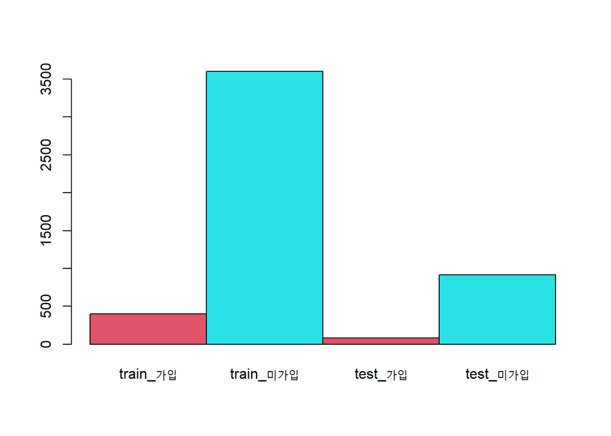

```r
#TrainSet과 TestSet을 생성한다.
bank_train <- bank_norm[1:4000,]
bank_test <- bank_norm[4001:5000,]

#target변수인 PersonalLoan은 초기 bank 데이터에서 label에 따로 저장한다.
bank_train_labels <- bank[1:4000,8]
bank_test_labels <- bank[4001:5000,8]

#TrainSet과 TestSet에서의 target변수 분포를 비교하기 위해 barplot을 그려보자
a <- table(bank_train_labels)
b <- table(bank_test_labels)
m <- matrix(c(a,b))
barplot(m, names=c("train_가입","train_미가입","test_가입","test_미가입"), beside = T, col = c(10,5))
```

```r
#비율로 보기 쉽게 ggplot의 누적막대그래프로 그려보자
#trainset이 accept비율이 미세하게 많으나 거의 동일한 것을 확인할 수 있다.
df1 <- data.frame( Set = c("trainSet","trainSet","testSet","testSet"), result=c("accept","reject","accept", "reject"), num = c(397,3603, 83, 917))
df1
```

```
##        Set result  num
## 1 trainSet accept  397
## 2 trainSet reject 3603
## 3  testSet accept   83
## 4  testSet reject  917
```

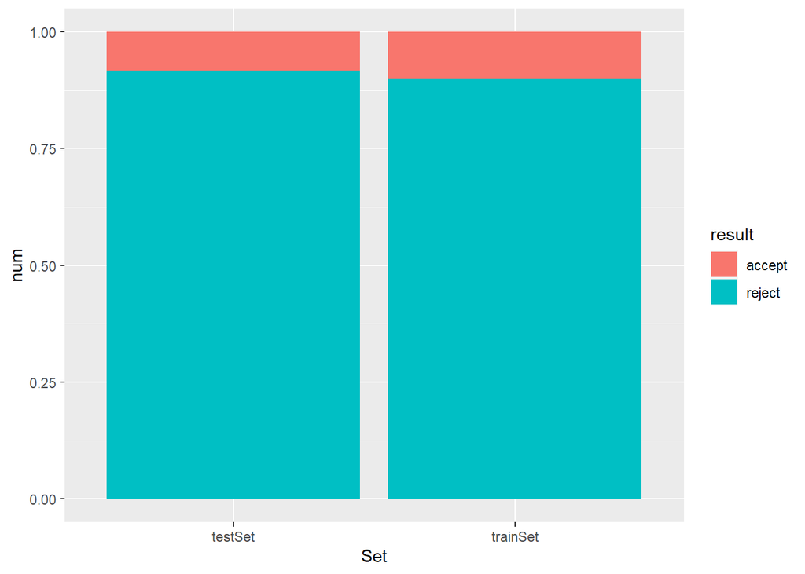

```r
ggplot(df1,aes(x=Set, y=num, fill=result))+geom_bar(stat="identity", position = "fill")
```

```r
#수치로 확인을 해보면
397/4000 #trainset
```

```
## [1] 0.09925
```

```r
83/1000  #testset
```

```
## [1] 0.083
```

```r
#거의 비슷하다.
```

=============================================================================================================== ##2번 5-NN을 적용하고 결과를 분석해보자

```r
#5-nn 적용
bank_test_pred <- knn(train=bank_train, test=bank_test, cl=bank_train_labels, k=5)
confusionMatrix(bank_test_pred, bank_test_labels)
```

```
## Confusion Matrix and Statistics
##
##                Reference
## Prediction      가입_accept 미가입_reject
##   가입_accept            49             4
##   미가입_reject          34           913
##
##                Accuracy : 0.962
##                  95% CI : (0.9482, 0.973)
##     No Information Rate : 0.917
##     P-Value [Acc > NIR] : 8.683e-09
##
##                   Kappa : 0.7013
##
##  Mcnemar's Test P-Value : 2.546e-06
##
##             Sensitivity : 0.5904
##             Specificity : 0.9956
##          Pos Pred Value : 0.9245
##          Neg Pred Value : 0.9641
##              Prevalence : 0.0830
##          Detection Rate : 0.0490
##    Detection Prevalence : 0.0530
##       Balanced Accuracy : 0.7930
##
##        'Positive' Class : 가입_accept
##
```

#분석 결과 : bank_test_pred모델로 bank_test를 돌려보면 Accuracy : True를 True로, False를 False로 옳게 예측한 경우를 고려한 지표로 (TP+TN = 49+913)/(전체=1000) = 0.962 즉 96.2%인 것을 확인할 수 있다. #Sensitivity는 실제 True값 중에 True를 예측한 비율로(TP=49)(TP+FN=49+34)=0.5904로 약 59%이다. 즉 실제 가입자중에서 가입자임을 맞춘 정도는 정확도와 비교했을때 많이 떨어진다. #이 문제에서 중요한 것은 새로운 고객을 대상으로 가입할지를 예측해야하기 때문에 Sensitivity가 높아야한다.

================================================================================================================

##3번 Training set 중 마지막 800명의 데이터를 validation set으로 사용하여 다양한 k에 대해 k-NN을 적용하고, 예측 성능을 비교해라. k가 어떤 값을 가질때 모델의 성능이 가장 우수한가?

```r
#trainset과 validationset 으로 나눠준다.
bank_train2 <- bank_norm[1:3200,]
bank_val <- bank_norm[3201:4000,]

#target인 PersonalLoan을 label에 따로 저장한다.
bank_train_labels2 <- bank[1:3200,8]
bank_val_labels <- bank[3201:4000,8]

str(bank_train2)
```

```
## 'data.frame':    3200 obs. of  11 variables:
##  $ Age              : num  -1.7742 -0.0295 -0.5529 -0.9019 -0.9019 ...
##  $ Experience       : num  -1.6659 -0.0963 -0.4451 -0.9683 -1.0555 ...
##  $ Income           : num  -0.538 -0.864 -1.364 0.57 -0.625 ...
##  $ Family           : num  1.397 0.526 -1.217 -1.217 1.397 ...
##  $ CCAvg            : num  -0.193 -0.251 -0.537 0.436 -0.537 ...
##  $ Education        : num  -1.049 -1.049 -1.049 0.142 0.142 ...
##  $ Mortgage         : num  -0.555 -0.555 -0.555 -0.555 -0.555 ...
##  $ SecuritiesAccount: num  2.929 2.929 -0.341 -0.341 -0.341 ...
##  $ CDAccount        : num  -0.254 -0.254 -0.254 -0.254 -0.254 ...
##  $ Online           : num  -1.22 -1.22 -1.22 -1.22 -1.22 ...
##  $ CreditCard       : num  -0.645 -0.645 -0.645 -0.645 1.549 ...
```

```r
str(bank_val)
```

```
## 'data.frame':    800 obs. of  11 variables:
##  $ Age              : num  0.232 -1.513 -1.338 -0.117 1.366 ...
##  $ Experience       : num  0.25248 -1.49151 -1.40431 -0.00912 1.29887 ...
##  $ Income           : num  -0.082 0.157 -1.06 0.982 -0.538 ...
##  $ Family           : num  -1.217 1.397 -0.345 -0.345 1.397 ...
##  $ CCAvg            : num  0.493 -0.994 -0.937 3.183 -0.136 ...
##  $ Education        : num  0.142 -1.049 -1.049 -1.049 0.142 ...
##  $ Mortgage         : num  -0.555 -0.555 -0.555 1.794 1.263 ...
##  $ SecuritiesAccount: num  -0.341 -0.341 2.929 -0.341 -0.341 ...
##  $ CDAccount        : num  -0.254 -0.254 -0.254 -0.254 -0.254 ...
##  $ Online           : num  -1.216 -1.216 0.822 0.822 -1.216 ...
##  $ CreditCard       : num  -0.645 -0.645 -0.645 -0.645 -0.645 ...
```

```r
#K를 바꿔보면서 예측모델을 살펴본다.
pred2_k1 <- knn(train=bank_train2, test=bank_val, cl=bank_train_labels2, k=1)
pred2_k5 <- knn(train=bank_train2, test=bank_val, cl=bank_train_labels2, k=5)
pred2_k9 <- knn(train=bank_train2, test=bank_val, cl=bank_train_labels2, k=9)
pred2_k11 <- knn(train=bank_train2, test=bank_val, cl=bank_train_labels2, k=11)
pred2_k21 <- knn(train=bank_train2, test=bank_val, cl=bank_train_labels2, k=21)
pred2_k30 <- knn(train=bank_train2, test=bank_val, cl=bank_train_labels2, k=30)

confusionMatrix(pred2_k1, bank_val_labels)  #0.9575 #0.6389
```

```
## Confusion Matrix and Statistics
##
##                Reference
## Prediction      가입_accept 미가입_reject
##   가입_accept            46             8
##   미가입_reject          26           720
##
##                Accuracy : 0.9575
##                  95% CI : (0.9411, 0.9704)
##     No Information Rate : 0.91
##     P-Value [Acc > NIR] : 1.763e-07
##
##                   Kappa : 0.7076
##
##  Mcnemar's Test P-Value : 0.003551
##
##             Sensitivity : 0.6389
##             Specificity : 0.9890
##          Pos Pred Value : 0.8519
##          Neg Pred Value : 0.9651
##              Prevalence : 0.0900
##          Detection Rate : 0.0575
##    Detection Prevalence : 0.0675
##       Balanced Accuracy : 0.8139
##
##        'Positive' Class : 가입_accept
##
```

```r
confusionMatrix(pred2_k5, bank_val_labels)  #0.9525 #0.5000
```

```
## Confusion Matrix and Statistics
##
##                Reference
## Prediction      가입_accept 미가입_reject
##   가입_accept            36             2
##   미가입_reject          36           726
##
##                Accuracy : 0.9525
##                  95% CI : (0.9354, 0.9662)
##     No Information Rate : 0.91
##     P-Value [Acc > NIR] : 3.590e-06
##
##                   Kappa : 0.6316
##
##  Mcnemar's Test P-Value : 8.636e-08
##
##             Sensitivity : 0.5000
##             Specificity : 0.9973
##          Pos Pred Value : 0.9474
##          Neg Pred Value : 0.9528
##              Prevalence : 0.0900
##          Detection Rate : 0.0450
##    Detection Prevalence : 0.0475
##       Balanced Accuracy : 0.7486
##
##        'Positive' Class : 가입_accept
##
```

```r
confusionMatrix(pred2_k9, bank_val_labels)  #0.9462 #0.44444
```

```
## Confusion Matrix and Statistics
##
##                Reference
## Prediction      가입_accept 미가입_reject
##   가입_accept            32             3
##   미가입_reject          40           725
##
##                Accuracy : 0.9462
##                  95% CI : (0.9283, 0.9608)
##     No Information Rate : 0.91
##     P-Value [Acc > NIR] : 8.569e-05
##
##                   Kappa : 0.573
##
##  Mcnemar's Test P-Value : 4.021e-08
##
##             Sensitivity : 0.44444
##             Specificity : 0.99588
##          Pos Pred Value : 0.91429
##          Neg Pred Value : 0.94771
##              Prevalence : 0.09000
##          Detection Rate : 0.04000
##    Detection Prevalence : 0.04375
##       Balanced Accuracy : 0.72016
##
##        'Positive' Class : 가입_accept
##
```

```r
confusionMatrix(pred2_k11, bank_val_labels) #0.9388 #0.37500
```

```
## Confusion Matrix and Statistics
##
##                Reference
## Prediction      가입_accept 미가입_reject
##   가입_accept            27             4
##   미가입_reject          45           724
##
##                Accuracy : 0.9388
##                  95% CI : (0.9198, 0.9543)
##     No Information Rate : 0.91
##     P-Value [Acc > NIR] : 0.001788
##
##                   Kappa : 0.497
##
##  Mcnemar's Test P-Value : 1.102e-08
##
##             Sensitivity : 0.37500
##             Specificity : 0.99451
##          Pos Pred Value : 0.87097
##          Neg Pred Value : 0.94148
##              Prevalence : 0.09000
##          Detection Rate : 0.03375
##    Detection Prevalence : 0.03875
##       Balanced Accuracy : 0.68475
##
##        'Positive' Class : 가입_accept
##
```

```r
confusionMatrix(pred2_k21, bank_val_labels) #0.9362 #0.33333
```

```
## Confusion Matrix and Statistics
##
##                Reference
## Prediction      가입_accept 미가입_reject
##   가입_accept            24             3
##   미가입_reject          48           725
##
##                Accuracy : 0.9362
##                  95% CI : (0.917, 0.9522)
##     No Information Rate : 0.91
##     P-Value [Acc > NIR] : 0.004162
##
##                   Kappa : 0.4583
##
##  Mcnemar's Test P-Value : 7.218e-10
##
##             Sensitivity : 0.33333
##             Specificity : 0.99588
##          Pos Pred Value : 0.88889
##          Neg Pred Value : 0.93790
##              Prevalence : 0.09000
##          Detection Rate : 0.03000
##    Detection Prevalence : 0.03375
##       Balanced Accuracy : 0.66461
##
##        'Positive' Class : 가입_accept
##
```

```r
confusionMatrix(pred2_k30, bank_val_labels) #0.93   #0.29167
```

```
## Confusion Matrix and Statistics
##
##                Reference
## Prediction      가입_accept 미가입_reject
##   가입_accept            20             4
##   미가입_reject          52           724
##
##                Accuracy : 0.93
##                  95% CI : (0.9101, 0.9467)
##     No Information Rate : 0.91
##     P-Value [Acc > NIR] : 0.02467
##
##                   Kappa : 0.3892
##
##  Mcnemar's Test P-Value : 3.372e-10
##
##             Sensitivity : 0.2778
##             Specificity : 0.9945
##          Pos Pred Value : 0.8333
##          Neg Pred Value : 0.9330
##              Prevalence : 0.0900
##          Detection Rate : 0.0250
##    Detection Prevalence : 0.0300
##       Balanced Accuracy : 0.6361
##
##        'Positive' Class : 가입_accept
##
```

```r
#더 많은 k 값을 k-nn에 적용해보고 어떤 분포를 이루는지 확인해보자=============================================
# 여러개의 k에 대한 accuracy 값과 sensitivity 값을 저장할 변수를 선언한다.

sens_k <- vector()
accur_k <- NULL

#k값은 1부터 99까지 2간격으로 for문을 이용해 k-nn에 적용한다. 앞서 만들었던 벡터 sens_k에는 sensitivity값을, accur_k에는 accurity 값을 저장하자.
for (kk in seq(1,99,2)){
  set.seed(1234)
  knn_k <- knn(train=bank_train2,test=bank_val,cl=bank_train_labels2,k=kk)
  sens_k[kk] <- sum((bank_val_labels=="가입_accept")&(knn_k == "가입_accept"))/sum(bank_val_labels=="가입_accept")
  accur_k <- c(accur_k, sum(knn_k == bank_val_labels)/length(bank_val_labels))
}

#for문이 잘 작동하여 저장되었는지 확인한다.
sens_k
```

```
##  [1] 0.6388889        NA 0.4583333        NA 0.5000000        NA 0.4305556
##  [8]        NA 0.4444444        NA 0.3750000        NA 0.3611111        NA
## [15] 0.3472222        NA 0.3333333        NA 0.3333333        NA 0.3333333
## [22]        NA 0.3055556        NA 0.2916667        NA 0.3055556        NA
## [29] 0.2777778        NA 0.2777778        NA 0.2500000        NA 0.2500000
## [36]        NA 0.2361111        NA 0.2361111        NA 0.2083333        NA
## [43] 0.1944444        NA 0.1944444        NA 0.1944444        NA 0.1944444
## [50]        NA 0.1944444        NA 0.1944444        NA 0.2083333        NA
## [57] 0.1944444        NA 0.2083333        NA 0.1805556        NA 0.1944444
## [64]        NA 0.1944444        NA 0.1666667        NA 0.1666667        NA
## [71] 0.1666667        NA 0.1666667        NA 0.1527778        NA 0.1388889
## [78]        NA 0.1527778        NA 0.1388889        NA 0.1388889        NA
## [85] 0.1388889        NA 0.1388889        NA 0.1250000        NA 0.1250000
## [92]        NA 0.1250000        NA 0.1250000        NA 0.1250000        NA
## [99] 0.1250000
```

```r
accur_k
```

```
##  [1] 0.95750 0.94750 0.95250 0.94500 0.94625 0.93875 0.93625 0.93500 0.93375
## [10] 0.93625 0.93625 0.93375 0.93250 0.93250 0.93000 0.93000 0.92750 0.92750
## [19] 0.92625 0.92625 0.92375 0.92250 0.92250 0.92250 0.92250 0.92125 0.92250
## [28] 0.92500 0.92375 0.92500 0.92250 0.92375 0.92375 0.92125 0.92125 0.92125
## [37] 0.92125 0.92000 0.91875 0.92000 0.91875 0.91875 0.91875 0.91875 0.91750
## [46] 0.91750 0.91750 0.91750 0.91750 0.91750
```

```r
#na.omit함수를 이용하여 NA값을 제거하고, 가장 높은 accuracy값과 Sensitivity값을 확인한다.
sensitivity <- na.omit(sens_k)
accuracy  <- na.omit(accur_k)

max(accuracy)
```

```
## [1] 0.9575
```

```r
max(sensitivity)
```

```
## [1] 0.6388889
```

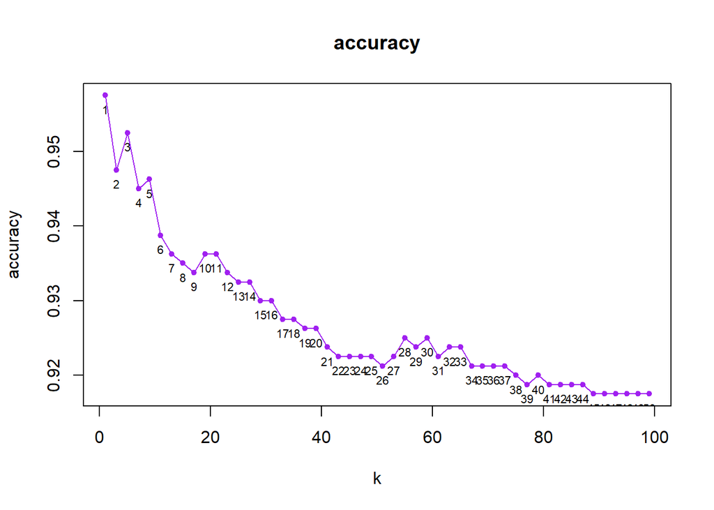

```r
#data.frame에 valid_k와 valid_k2로 저장하고, plot함수를 이용해 나타냈다.
valid_k <- data.frame( k = seq(1,99,2), accuracy=accuracy)
valid_k2 <- data.frame( k = seq(1,99,2), sensitivity=sensitivity)

#accuracy
plot(valid_k,type="o",col = "purple",pch=20, main="accuracy")
with(valid_k, text(accuracy ~ k, labels = rownames(valid_k), pos = 1, cex = 0.7))
```

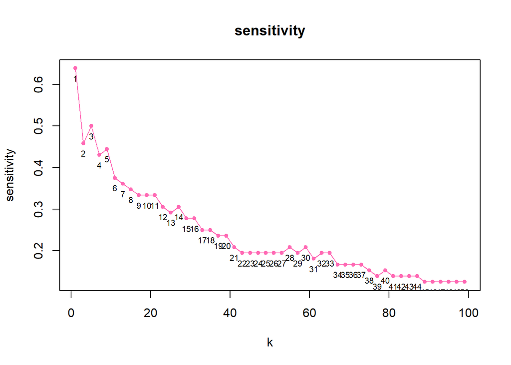

```r
#sensitivity
plot(valid_k2,type="o",col = "hotpink",pch=20, main="sensitivity")
with(valid_k2, text(sensitivity ~ k, labels = rownames(valid_k2), pos = 1, cex = 0.7))
```

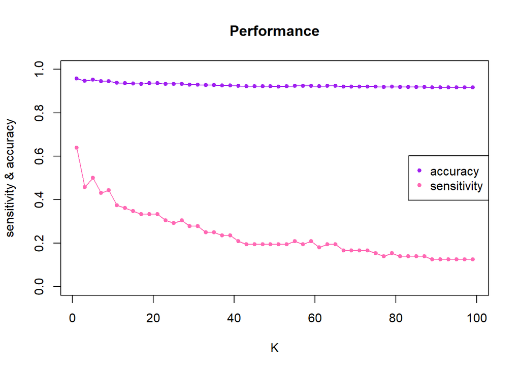

```r
#accuracy & sensitivity
plot(valid_k, type = 'o', col = 'purple', pch=20, ylim = c(0,1), ylab="sensitivity & accuracy", xlab= "K", main="Performance")  # 첫 번째 그려진 그래프의 눈금으로 틀이 고정됩니다.
lines(valid_k2, type = 'o', col = 'hotpink', pch=20)
legend("right",c("accuracy", "sensitivity"), col = c("purple","hotpink"), pch = c(20,20))
```

```r
# K=1일 때 가장 성능이 우수하다.
```

k=1일때 Accuracy가 0.9575 즉 95.75%로 가장 높다. 그리고 이때 모델의 Sensitivity는 0.6389인 63.89%이다. accuracy 그래프나 sensitivity 그래프 모두 k가 커질수록 감소하는 모습이 보인다. 마지막 그래프를 보면 k가 커질수록 accuracy와 비교했을때 sensitivity 값이 급격이 감소하는데 이러한 Sensitivity 때문에 전반적인 모델 성능이 낮아진다.

==================================================================================================================

##4번 training set에 대해 5-fold cross validation을 5회 반복하여 best k 값을 찾아보자. best k 값으로 만들어지는 최종 model에 test set을 적용하여 model의 성능을 report하자.

```r
bank_train3 <- bank[1:4000,]
bank_test3 <- bank[4001:5000,]

#train 함수에 들어갈 파라미터 값들을 먼저 넣어준다. train함수를 사용하기 전에는 set.seed()를 이용해 고정시켜준다.
cv=trainControl(method="repeatedcv", number=5, repeats = 5)
tune_grid <- data.frame(k=seq(1,99,2))
z_norm <- c("center", "scale")
set.seed(777)

# 5-Fold Cross Validation을 5회 반복해 knn_fit 변수에 저장한다.
knn_fit <- train(data = bank_train3, PersonalLoan~., method="knn",  trControl = cv, preProcess= z_norm, tuneGrid = tune_grid)

# Best K는 3이다.
knn_fit
```

```
## k-Nearest Neighbors
##
## 4000 samples
##   11 predictor
##    2 classes: '가입_accept', '미가입_reject'
##
## Pre-processing: centered (11), scaled (11)
## Resampling: Cross-Validated (5 fold, repeated 5 times)
## Summary of sample sizes: 3200, 3200, 3200, 3200, 3200, 3200, ...
## Resampling results across tuning parameters:
##
##   k   Accuracy   Kappa
##    1  0.9544520  0.7184168
##    3  0.9569522  0.7172783
##    5  0.9545520  0.6944371
```

[output cut: 50 more lines]

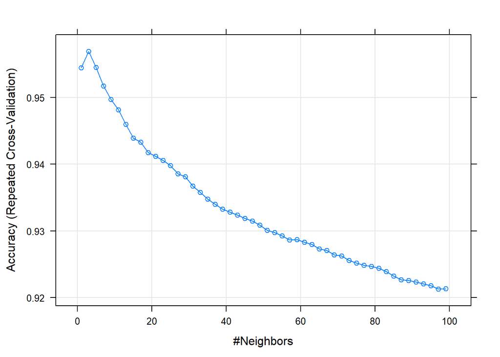

```r
# plot을 그려 k 변화에 따른 accuracy를 확인한다.
plot(knn_fit, )
```

```r
#Best K로 만들어지는 최종 model에 test set을 적용하고 성능을 report하자

test_pred <- predict(knn_fit, bank_test3[,-8])
confusionMatrix(test_pred, bank_test3[,8], positive="가입_accept")
```

```
## Confusion Matrix and Statistics
##
##                Reference
## Prediction      가입_accept 미가입_reject
##   가입_accept            54             4
##   미가입_reject          29           913
##
##                Accuracy : 0.967
##                  95% CI : (0.954, 0.9772)
##     No Information Rate : 0.917
##     P-Value [Acc > NIR] : 9.350e-11
##
##                   Kappa : 0.7488
##
##  Mcnemar's Test P-Value : 2.943e-05
##
##             Sensitivity : 0.6506
##             Specificity : 0.9956
##          Pos Pred Value : 0.9310
##          Neg Pred Value : 0.9692
##              Prevalence : 0.0830
##          Detection Rate : 0.0540
##    Detection Prevalence : 0.0580
##       Balanced Accuracy : 0.8231
##
##        'Positive' Class : 가입_accept
##
```

best k = 3으로 만든 최종 3-NN 모델에 test set을 적용했더니 정확도는 0.967 즉 96.7%로 높게 나왔다. 이때 sensitivity는 0.6506, specificity는 0.9956이 나왔다. 상대적으로 높은 accuracy와 sensitivity를 봤을 때 3-NN 모델은 상당히 유의하고 신뢰할 수 있는 모델이라고 볼 수 있다.

============================================================================================================== ##5. 3번과 4번에서 활용한 training방식의 장단점을 비교해보자

보편적인 모델의 성능 테스트 방법은 원 데이터를 훈련데이터와 테스트데이터 두개로 나누는 것이다. 하지만 이 방법은 모델을 만드는 과정에서 동일한 데이터셋으로 계속 재사용하게 되고, 훈련데이터의 의미가 사라지며 과적합되기 쉽다.

3번에서 사용한 방법은 Hold out validation(홀드아웃 메서드)으로 데이터를 세 부분으로 나누게 된다. 1. train data -> a. train b. validation 2. test data 즉 ((훈련데이터, 검증데이터), 테스트데이터) 세 개로 나뉜다. 여기서의 훈련 데이터는 말 그대로 훈련 데이터이고, 검증 데이터에 대한 성능을 높이는 작업을 학습에서 진행한다. 그리고 테스트 데이터를 이용하여 최종 성능을 추정하게 된다.

홀드아웃 교차검증의 큰 단점은 데이터셋 전체가 개수가 크지 않다면, 결과에 영향을 크게 미친다. 또한 한개의 데이터 셋으로 모델의 성능을 평가하기 때문에 각 데이터셋이 전체 데이터를 통계적으로 대표하지 못할 가능성이 높다. 즉, 하나의 데이터셋에 다양한 특징을 지닌 데이터들이 포함되지 않을 수 있다는 것이다.

이를 확인하는 방법으로는 새롭게 데이터를 셔플링하여 다시 모델을 학습시켰을 때 모델의 성능이 많이 차이가 난다면 이 문제라고 볼 수 있다.

4번에서 사용한 K-fold cross validation(교차 검증) 방벙은 K번만큼 검증 데이터셋과 훈련 데이터셋을 변경해가면서 거의 모든 데이터에 대해 검증을 하는 방법이다. 4번에서는 5 * 5 = 25개의 validation set에 대해 model 성능을 계산한 뒤, 이들의 평균으로 model을 평가하였다.

k-fold cv의 장점으로는 평가에 사용되는 데이터 편중을 막을 수 있고, overfitting이 되는 것을 방지할 수 있다. 또한 모든 데이터 셋을 훈련에 활용할 수 있어 정확도를 향상시키고, 데이터 부족으로 인한 underfitting을 방지할 수 있다. 단점으로는 모델 훈련, 평가 시간이 오래 걸린다는 점이 있다.